# Module 7: Solutions to recommended Exercises

TMA4268 Statistical Learning V2025

Sara Martino, Stefanie Muff, Kenneth Aase

Department of Mathematical Sciences, NTNU

Feb 28, 2025

## Problem 1

The code below performs polynomial regression of degree $1$, $2$, $3$ and $4$. The function `sapply()` is an efficient for-loop. We iterate over all degrees to plot the fitted values and compute the test error. Finally we plot the test error for each polynomial degree.

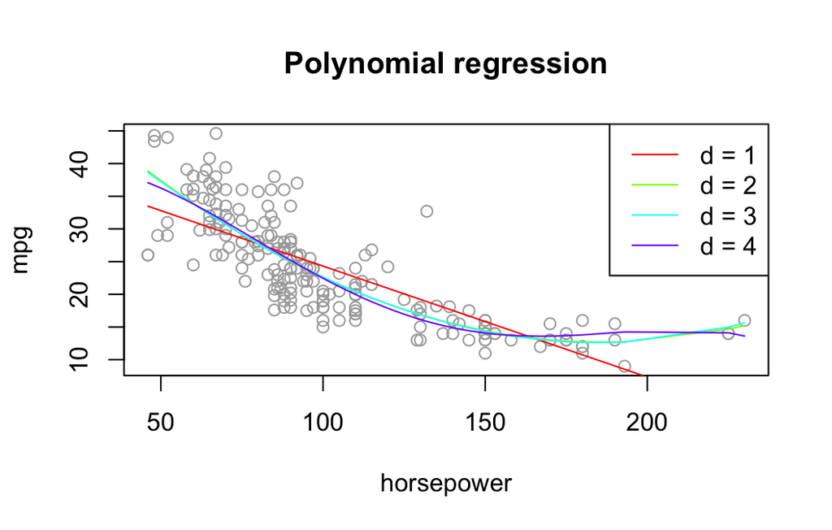

```r
library(ISLR)
# extract only the two variables from Auto
ds <- Auto[c("horsepower", "mpg")]
n <- nrow(ds)
# which degrees we will look at
deg <- 1:4
set.seed(1)
# training ids for training set
tr <- sample.int(n, n / 2)
# plot of training data
plot(ds[tr, ], col = "darkgrey", main = "Polynomial regression")

# which colors we will plot the lines with
co <- rainbow(length(deg))
# iterate over all degrees (1:4) - could also use a for-loop here
MSE <- sapply(deg, function(d) {
  # fit model with this degree
  mod <- lm(mpg ~ poly(horsepower, d), ds[tr, ])
  # add lines to the plot
  # use fitted values (for mpg) and horsepower from training set
  lines(cbind(ds[tr, 1], mod$fit)[order(ds[tr, 1]), ], col = co[d])
  # calculate mean MSE - this is returned in the MSE variable
  mean((predict(mod, ds[-tr, ]) - ds[-tr, 2])^2)
})
# add legend to see which color corresponds to which line
legend("topright", legend = paste("d =", deg), lty = 1, col = co)
```

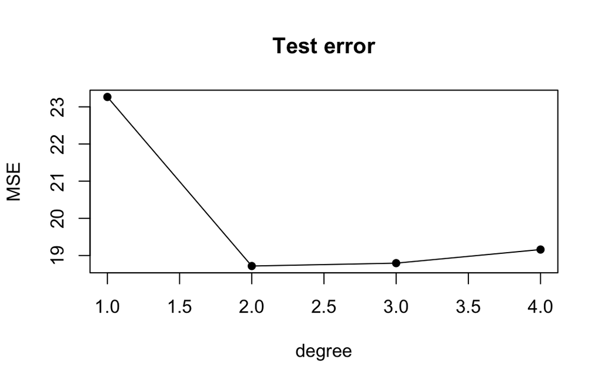

```r
# plot MSE
plot(MSE, type = "o", pch = 16, xlab = "degree", main = "Test error")
```

The same solution using `ggplot` is shown below.

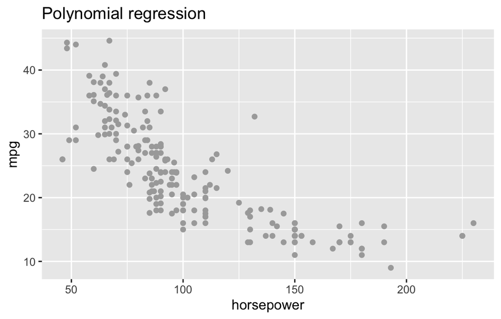

```r
# solution with ggplot
library(ISLR)
library(ggplot2)
# extract only the two variables from Auto
ds <- Auto[c("horsepower", "mpg")]
n <- nrow(ds)
# which degrees we will look at
deg <- 1:4
set.seed(1)
# training ids for training set
tr <- sample.int(n, n / 2)
# plot of training data
ggplot(data = ds[tr, ], aes(x = horsepower, y = mpg)) +
  geom_point(color = "darkgrey") +
  labs(title = "Polynomial regression")
```

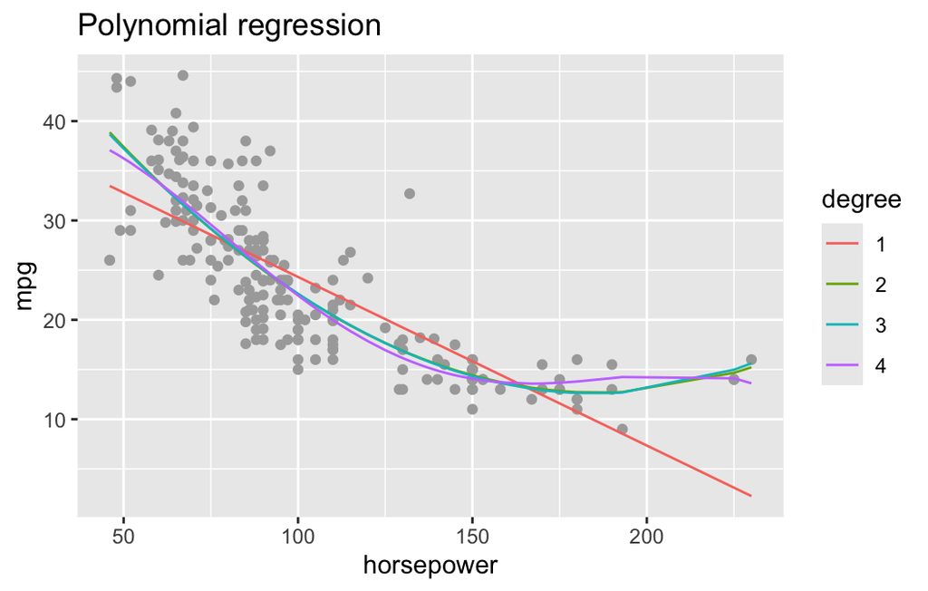

```r
# iterate over all degrees (1:4) - could also use a for-loop here
dat <- c() # make a empty variable to store predicted values
for (d in deg) {
  # fit model with this degree
  mod <- lm(mpg ~ poly(horsepower, d), ds[tr, ])
  # data frame of predicted values - use fitted values (for mpg) and horsepower
  # from training set and add column (factor) for degree
  dat <- rbind(dat, data.frame(
    horsepower = ds[tr, 1], mpg = mod$fit,
    degree = as.factor(rep(d, length(mod$fit)))
  ))
  # calculate mean MSE - this is returned in the MSE variable
  MSE[d] <- mean((predict(mod, ds[-tr, ]) - ds[-tr, 2])^2)
}
# plot fitted values for different degrees
ggplot(data = ds[tr, ], aes(x = horsepower, y = mpg)) +
  geom_point(color = "darkgrey") +
  labs(title = "Polynomial regression") +
  geom_line(data = dat, aes(x = horsepower, y = mpg, color = degree))
```

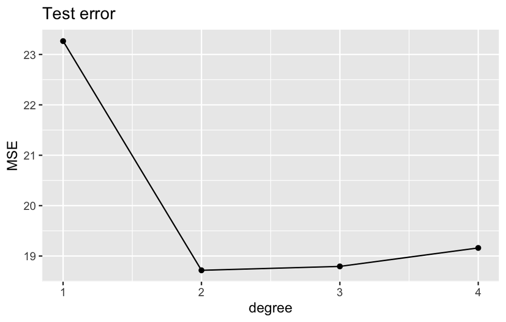

```r
# plot MSE
MSEdata <- data.frame(MSE = MSE, degree = 1:4)
ggplot(data = MSEdata, aes(x = degree, y = MSE)) +
  geom_line() +
  geom_point() +
  labs(title = "Test error")
```

## Problem 2

We use `factor(origin)` for conversion to a factor variable. The function `predict(..., se = TRUE)` gives fitted values with standard errors.

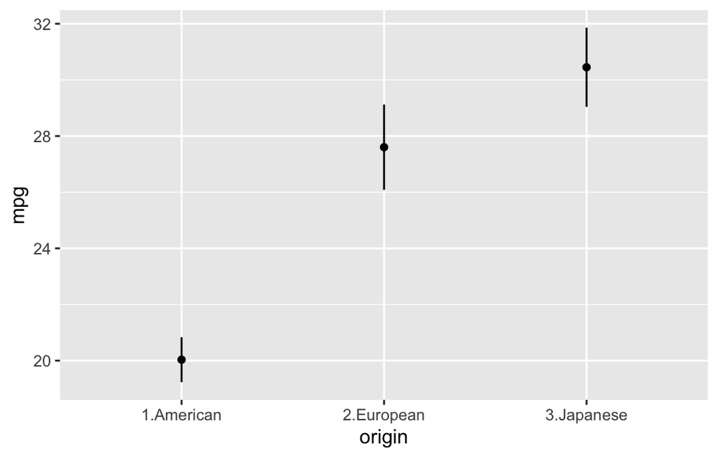

```r
attach(Auto)
# fit model
fit <- lm(mpg ~ factor(origin))
# make a new dataset of the origins to predict the mpg for the different origins
new <- data.frame(origin = as.factor(sort(unique(origin))))
# predicted values and standard errors
pred <- predict(fit, new, se = TRUE)
# data frame including CI (z_alpha/2 = 1.96)
dat <- data.frame(
  origin = new, mpg = pred$fit,
  lwr = pred$fit - 1.96 * pred$se.fit,
  upr = pred$fit + 1.96 * pred$se.fit)

# plot the fitted/predicted values and CI
ggplot(dat, aes(x = origin, y = mpg)) +
  geom_point() +
  geom_segment(aes(x = origin, y = lwr, xend = origin, yend = upr)) +
  scale_x_discrete(labels = c("1" = "1.American",
                              "2" = "2.European",
                              "3" = "3.Japanese"))
```

## Problem 3

The request is a design matrix $X$ for a natural cubic spline with $X =$ `year` and one internal knot at $2006$. The definition of the basis for a natural cubic spline is
$$b_1(x_i) = x_i, \quad b_{k+2}(x_i) = d_k(x_i)-d_K(x_i),\; k = 0, \ldots,
K - 1,\\$$

$$d_k(x_i) = \frac{(x_i-c_k)^3_+-(x_i-c_{K+1})^3_+}{c_{K+1}-c_k},$$

where $K$ is the number of internal knots, $c_k$ is the location of the $k^\text{th}$ knot, and $(.)_+$ denotes $\max (., 0)$. In our case we have one internal knot at $c_1 = 2006$, thus $K = 1$. Since this is a natural spline, the boundary knots should be the extreme values of `year`, that is $c_0 = 2003$ and $c_2 = 2009$. Since $K=1$, the index $k$ takes only the value $0$, so we end up with only having to find $b_1(x_i)$ and $b_2(x_i)$.

By inserting into the above expressions, we find that the two basis functions are

$$\begin{align*}
b_1(x_i) &= x_i,\\
b_2(x_i) &= d_0(x_i)-d_1(x_i)\\
&= \frac{(x_i-c_0)^3_+-(x_i-c_2)^3_+}{c_2-c_0} -
\frac{(x_i-c_1)^3_+-(x_i-c_2)^3_+}{c_2-c_1}\\
&= \frac{1}{c_2-c_0}(x_i-c_0)^3_+ - \frac{1}{c_2-c_1}(x_i-c_1)^3_+ +
\left(\frac{1}{c_2-c_1}-\frac{1}{c_2-c_0}\right)(x_i-c_{2})^3_+\\
&= \frac{1}{6}(x_i-2003)^3_+ - \frac{1}{3}(x_i-2006)^3_+ +
\frac{1}{6}(x_i-2009)^3_+.
\end{align*}$$

We can simplify the final term in the second basis function by using the fact that the boundary knots are the extreme values of $x_i$, that is $2003 \leq x_i \leq 2009$, and thus $\frac{1}{6}(x_i-2009)^3_+=0$. Thus,

$$b_2(x_i) = \frac{1}{6}(x_i-2003)^3 - \frac{1}{3}(x_i-2006)^3_+.$$

The design matrix (here also including an intercept term) is given by

$$\mathbf X = \begin{pmatrix}
1 & b_{1}(x_1) & b_{2}(x_1) \\
1 & b_{1}(x_2) & b_{2}(x_2) \\
\vdots & \vdots & \vdots \\
1 & b_{1}(x_n) & b_{2}(x_n) \\
\end{pmatrix},$$

where $b_1(x_i)$ and $b_2(x_i)$ are as found above.

## Problem 4

The matrix $\mathbf X$ is obtained by using `cbind()` to join an intercept, a cubic spline, a natural cubic spline and a factor.

```r
library(ISLR)
attach(Wage)
# install.packages("gam")
library(gam)

# Write a couple of functions first, which will be used to produce the
# components of the design matrix.
# We write separate functions to generate X_1, X_2 and X_3 (the three components
# of the model)
# X_1: The function mybs() generates basis functions for the cubic spline
mybs <- function(x, knots) {
  cbind(x, x^2, x^3, sapply(knots, function(y) pmax(0, x - y)^3))
}

# X_2: The function myns generates basis functions for the natural cubic spline;
# d() is a helper function
d <- function(c, cK, x) {
  (pmax(0, x - c)^3 - pmax(0, x - cK)^3) / (cK - c)
}
myns <- function(x, knots) {
  kn <- c(min(x), knots, max(x))
  K <- length(kn)
  sub <- d(kn[K - 1], kn[K], x)
  cbind(x, sapply(kn[1:(K - 2)], d, kn[K], x) - sub)
}

# X_3: The function myfactor() generates the dummy-basis functions for a factor
# covariate, building on the R-function model.matrix()
myfactor <- function(x) {
  model.matrix(~x)[, -1]
}

# Once these functions are prepared, we can generate the model matrix
# X = (1,X_1, X_2, X_3) as a one-liner
X <- cbind(1, mybs(age, c(40, 60)), myns(year, 2006), myfactor(education))
```

We have now created a model matrix $\mathbf X$ “by hand”. The thing we wanted to illustrate with this exercise is that this hand-made matrix does not correspond to the internal representation of the model matrix that we would direclty get using the `gam()` function:

```r
X_gam <- model.matrix(~ bs(age, knots = c(40, 60)) +
                        ns(year, knots = 2006) +
                        education)
```

```r
# Anyway, if we now use our model matrix to fit a linear regression model
# (excluding the intercept -1, because the first column of X already contains
# only 1's and thus encodes for an intercept), we can obtain predicted values
# for yhat
myhat <- lm(wage ~ X - 1)$fit

# Comparing to the fitted values with gam shows that they are all equal
# (all.equal() will indicate TRUE)
yhat <- gam(wage ~ bs(age, knots = c(40, 60)) +
              ns(year, knots = 2006) +
              education)$fit
all.equal(myhat, yhat)
```

```
## [1] TRUE
```

The fitted values `myhat` and `yhat` are equal. Both the design matrices $\mathbf X$ and the coefficients $\hat{\beta}$ differs, but $\mathbf X \hat{\beta}$ are the same. How can this be? Well, just as there were several ways to represent polynomials, there are also many equivalent ways to represent splines or factor variables using different choices of basis functions.

## Problem 5

```
##
## Call: gam(formula = mpg ~ bs(displacement, knots = c(290)) + poly(horsepower,
##     2) + weight + s(acceleration, df = 3) + origin, data = Auto)
## Deviance Residuals:
##      Min       1Q   Median       3Q      Max
## -11.5172  -2.3774  -0.2538   1.7982  15.9994
##
## (Dispersion Parameter for gaussian family taken to be 14.1747)
##
##     Null Deviance: 23818.99 on 391 degrees of freedom
## Residual Deviance: 5372.203 on 378.9999 degrees of freedom
## AIC: 2166.599
##
## Number of Local Scoring Iterations: NA
##
## Anova for Parametric Effects
##                                   Df  Sum Sq Mean Sq  F value    Pr(>F)
## bs(displacement, knots = c(290))   4 16705.2  4176.3 294.6301 < 2.2e-16 ***
## poly(horsepower, 2)                2  1283.6   641.8  45.2786 < 2.2e-16 ***
## weight                             1   318.9   318.9  22.4970 2.985e-06 ***
## s(acceleration, df = 3)            1   128.1   128.1   9.0362 0.0028231 **
## origin                             2   213.8   106.9   7.5422 0.0006137 ***
## Residuals                        379  5372.2    14.2
## ---
## Signif. codes:  0 '***' 0.001 '**' 0.01 '*' 0.05 '.' 0.1 ' ' 1
##
## Anova for Nonparametric Effects
##                                  Npar Df Npar F   Pr(F)
## (Intercept)
## bs(displacement, knots = c(290))
## poly(horsepower, 2)
## weight
## s(acceleration, df = 3)                2 2.9111 0.05563 .
## origin
## ---
## Signif. codes:  0 '***' 0.001 '**' 0.01 '*' 0.05 '.' 0.1 ' ' 1
```

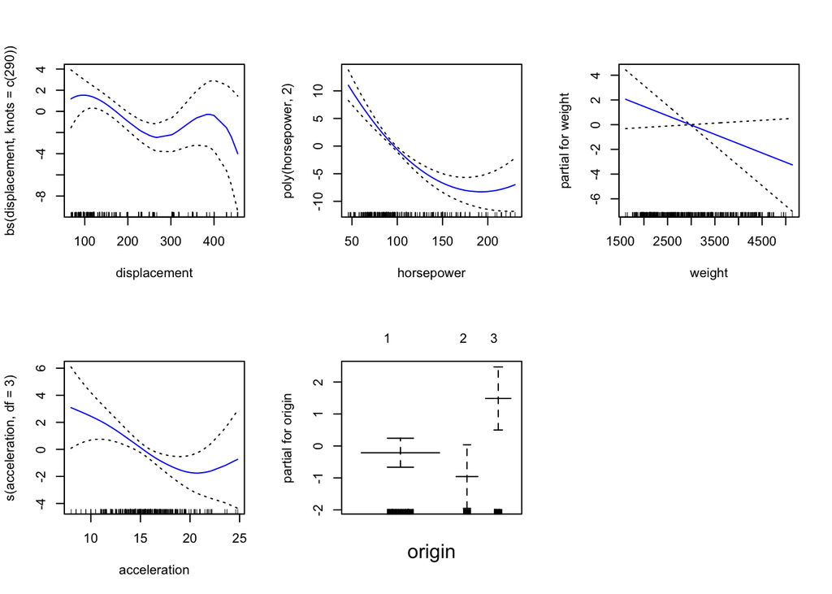

```r
library(gam)
# first set origin as a factor variable
Auto$origin <- as.factor(Auto$origin)
# gam model
fitgam <- gam(mpg ~ bs(displacement, knots = c(290)) +
  poly(horsepower, 2) + weight + s(acceleration, df = 3) +
  origin, data = Auto)
# plot covariates
par(mfrow = c(2, 3))
plot(fitgam, se = TRUE, col = "blue")
# summary of fitted model
summary(fitgam)
```